# Example 3.1 Can Dogs Sniff Out Cancer?

Last updated Thursday, October 08, 2026 @ 05:40 PM

## Before We Begin…

These slides are meant to accompany the text [*Introduction to Statistical Investigations, 2nd Edition*](http://www.isi-stats.com/isi/index2nd.html) — Section 3.1 Statistical Inference: Confidence Intervals.

*This content does not replace reading the relevant textbook section.* It is for class presentation, review, and reference.

## Overview of the Study

Researchers tested a dog named Marine to see whether or not she could detect colorectal cancer via smell. She sniffed breath in 5 bags from 5 different patients, only 1 of which had cancer. This process was repeated many times. Marine chose correctly in 30 out of 33 trials (sets of bags), so \(\hat{p} = 0.909\).

\(H_0: \pi = 0.20\) (Marine is just guessing, 1 in 5 chance)  
\(H_a: \pi > 0.20\) (Marine is doing better than guessing)

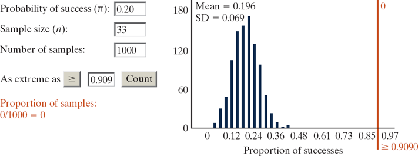

We would reject \(H_0: \pi = 0.20\) at the \(0.05\) significance level. So, what is Marine’s true probability \(\pi\) of detecting cancer? We can estimate this parameter by testing many potential values of \(\pi\) on either side of Marine’s sample proportion \(\hat{p} = 0.909\).

[output not shown]

We are 95% confident that Marine’s true probability of detecting cancer (\(\pi\)) is between \(0.761\) and \(0.974\). Much better than \(20\%\)! This is more informative than simply concluding \(\pi > 0.20\) (\(H_a\)).

## The Test for \(H_0: \pi = 0.760\)

The two-sided *p*-value \(≤ 0.05\). We reject \(0.760\) as a plausible value for \(\pi\). It *will not* be in our confidence interval. Any value even farther below \(\hat{p} = 0.909\) also *will not* be in the interval.

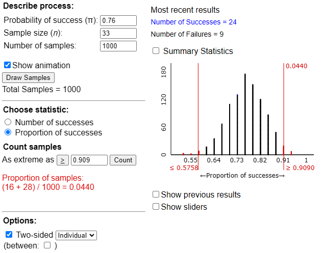

## The Test for \(H_0: \pi = 0.761\)

Because the two-sided *p*-value is more than \(0.05\), \(\pi = 0.761\) is considered a plausible value. **It will be included the confidence interval** and it is the lower boundary. All values between \(0.761\) and \(\hat{p} = 0.909\) also will be in the interval.

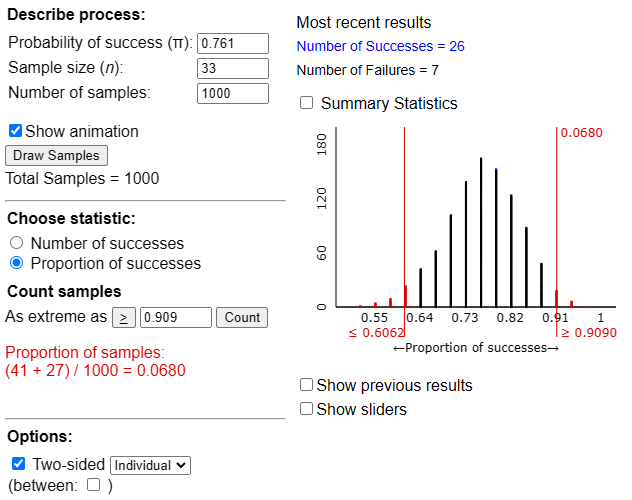

## The Test for \(H_0: \pi = 0.909\)

When \(\pi = \hat{p}\), the *p*-value is \(1.000\). Note that all the tests in this method use \(\hat{p} = 0.909\) to assess the potential values of \(\pi\). *The data is the evidence on which our estimate is based.*

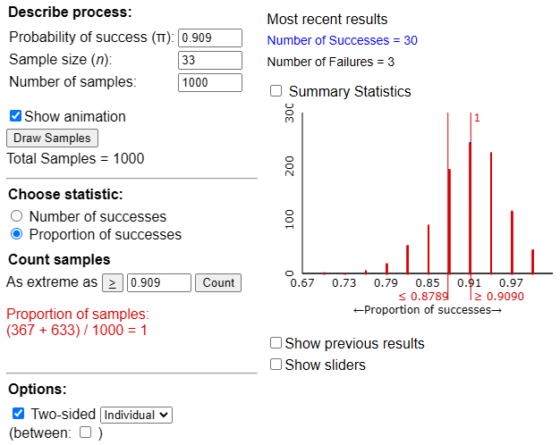

## The Test for \(H_0: \pi = 0.974\)

The two-sided *p*-value \(> 0.05\), so \(\pi = 0.974\) will be considered a plausible value and **will be included the confidence interval**. Any potential value between \(\hat{p} = 0.909\) and \(0.974\) also will be in the interval. As we will see, this is the upper boundary.

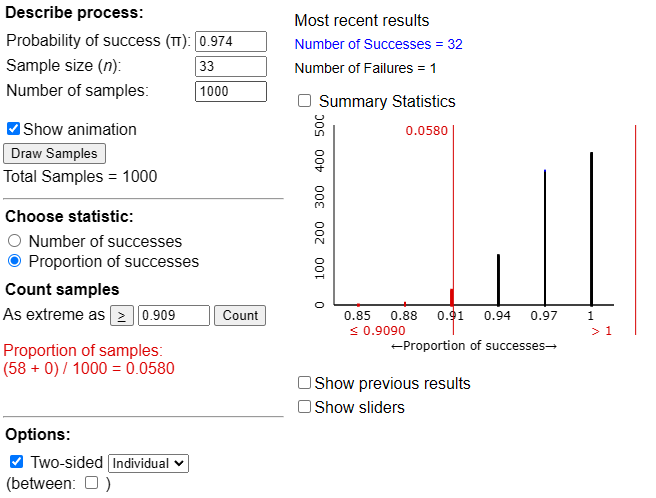

## The Test for \(H_0: \pi = 0.975\)

The two-sided *p*-value \(≤ 0.05\). We reject \(0.975\) as a plausible value for \(\pi\). It *will not* be in our confidence interval. Any value even farther above \(\hat{p} = 0.909\) also *will not* be in the interval.

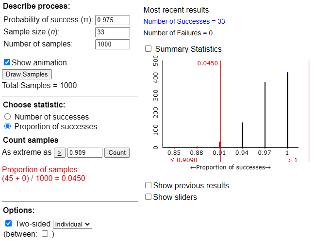

## So Many Tests!

Our final interval is \((0.761, 0.974)\). We used *p*-value \(\leq 0.05\) to reject \(H_0\), so the level of confidence is \(100\% - 5\% = 95\%\).

In this context, finding a 95% confidence interval with 3 decimal places, using the method of plausible values, would require over \(200\) significance tests, or one for every potential value of \(\pi\) we need to evaluate. Using logic, we can reduce this.

A 99% confidence interval determined by this method would be wider and require even more tests! *More* confidence means the interval will contain *more* plausible values.

So why did we do this? The point is to connect our significance testing to confidence intervals, and level of significance to level of confidence. The two methods are inherently connected.